# R Cookbook - Chapter 11 - Linear Regression and ANOVA

The lm function can perform linear regression. The main argument is a model formula, such as y ~ x. The formula has the response variable on the left of the tilde character (~) and the predictor variable on the right. The function estimates the regression coefficients, β0 and β1, and reports them as the intercept and the coefficient of x, respectively.

```r
head(mtcars)
```

| mpg | cyl | disp | hp | drat | wt | qsec | vs | am | gear | carb |
| --- | --- | --- | --- | --- | --- | --- | --- | --- | --- | --- |
| 21.0 | 6 | 160 | 110 | 3.90 | 2.620 | 16.46 | 0 | 1 | 4 | 4 |
| 21.0 | 6 | 160 | 110 | 3.90 | 2.875 | 17.02 | 0 | 1 | 4 | 4 |
| 22.8 | 4 | 108 | 93 | 3.85 | 2.320 | 18.61 | 1 | 1 | 4 | 1 |
| 21.4 | 6 | 258 | 110 | 3.08 | 3.215 | 19.44 | 1 | 0 | 3 | 1 |
| 18.7 | 8 | 360 | 175 | 3.15 | 3.440 | 17.02 | 0 | 0 | 3 | 2 |
| 18.1 | 6 | 225 | 105 | 2.76 | 3.460 | 20.22 | 1 | 0 | 3 | 1 |

```r
lm(mtcars$mpg ~ mtcars$hp)
```

```
##
## Call:
## lm(formula = mtcars$mpg ~ mtcars$hp)
##
## Coefficients:
## (Intercept)    mtcars$hp
##    30.09886     -0.06823
```

```r
lm(mpg ~ hp, data=mtcars)
```

```
##
## Call:
## lm(formula = mpg ~ hp, data = mtcars)
##
## Coefficients:
## (Intercept)           hp
##    30.09886     -0.06823
```

Where the equation of the line is yi = 30.09886 - 0.06823xi + εi

R uses the lm function for both simple and multiple linear regression. You simply add more variables to the righthand side of the model formula.

```r
lm(formula=mpg ~ hp + wt + disp, data=mtcars)
```

```
##
## Call:
## lm(formula = mpg ~ hp + wt + disp, data = mtcars)
##
## Coefficients:
## (Intercept)           hp           wt         disp
##   37.105505    -0.031157    -3.800891    -0.000937
```

You want the critical statistics and information regarding your regression, such as R^2, the F statistic, confidence intervals for the coefficients, residuals, the ANOVA table, and so forth.

```r
m <- lm(mpg ~ hp + wt + disp, data=mtcars)
m
```

```
##
## Call:
## lm(formula = mpg ~ hp + wt + disp, data = mtcars)
##
## Coefficients:
## (Intercept)           hp           wt         disp
##   37.105505    -0.031157    -3.800891    -0.000937
```

ANOVA table

```r
anova(m)
```

| Df | Sum Sq | Mean Sq | F value | Pr(>F) |
| --- | --- | --- | --- | --- |
| 1 | 678.37287396 | 678.37287396 | 97.412045463 | 1.284511e-10 |
| 1 | 252.62655880 | 252.62655880 | 36.276317607 | 1.720378e-06 |
| 1 | 0.05708002 | 0.05708002 | 0.008196498 | 9.285070e-01 |
| 28 | 194.99067472 | 6.96395267 | NA | NA |

Model coefficients

```r
coef(m)
```

```
##   (Intercept)            hp            wt          disp
## 37.1055052690 -0.0311565508 -3.8008905826 -0.0009370091
```

Confidence intervals for the regression coefficients

```r
confint(m)
```

```
##                   2.5 %       97.5 %
## (Intercept) 32.78169625 41.429314293
## hp          -0.05458171 -0.007731388
## wt          -5.98488310 -1.616898063
## disp        -0.02213750  0.020263482
```

Residual sum of squares (for linear models the deviance equals the RSS, aka sum of squared errors of prediction).

```r
deviance(m)
```

```
## [1] 194.9907
```

Vector of orthogonal effects

```r
effects(m)
```

```
##  (Intercept)           hp           wt         disp
## -113.6497374  -26.0455922  -15.8942304    0.2389143    0.6007568
##
##   -2.1759684   -1.0063506    1.7963476    1.1627042   -0.5057907
##
##   -1.9057907    0.7285209    0.4392237   -1.4858796   -0.4418080
##
##    0.5089867    5.0472368    6.5130808    2.0011906    6.7080828
##
##   -2.4525486   -3.1260065   -3.7138443   -1.0551326    2.4903152
##
##    0.4859253    0.7100738    3.6687964   -0.2647815   -0.5971718
##
##    2.7398359   -1.0504820
## attr(,"assign")
## [1] 0 1 2 3
## attr(,"class")
## [1] "coef"
```

Vector of fitted y values

```r
fitted(m)
```

```
##           Mazda RX4       Mazda RX4 Wag          Datsun 710
##           23.570030           22.600803           25.288683
##      Hornet 4 Drive   Hornet Sportabout             Valiant
##           21.216673           18.240722           20.472159
##          Duster 360           Merc 240D            Merc 230
##           15.565648           22.911499           22.040897
##            Merc 280           Merc 280C          Merc 450SE
##           20.041143           20.041143           15.769274
##          Merc 450SL         Merc 450SLC  Cadillac Fleetwood
##           17.061577           16.871533           10.321469
## Lincoln Continental   Chrysler Imperial            Fiat 128
##            9.359792            9.211454           26.613471
##         Honda Civic      Toyota Corolla       Toyota Corona
##           29.275995           28.039074           24.601590
##    Dodge Challenger         AMC Javelin          Camaro Z28
##           18.754919           19.091113           14.548777
##    Pontiac Firebird           Fiat X1-9       Porsche 914-2
##           16.663881           27.620426           26.023631
##        Lotus Europa      Ford Pantera L        Ferrari Dino
##           27.744958           16.502463           20.988776
##       Maserati Bora          Volvo 142E
##           12.816842           23.029587
```

Model residuals

```r
residuals(m)
```

```
##           Mazda RX4       Mazda RX4 Wag          Datsun 710
##          -2.5700299          -1.6008028          -2.4886829
##      Hornet 4 Drive   Hornet Sportabout             Valiant
##           0.1833269           0.4592780          -2.3721590
##          Duster 360           Merc 240D            Merc 230
##          -1.2656477           1.4885011           0.7591033
##            Merc 280           Merc 280C          Merc 450SE
##          -0.8411432          -2.2411432           0.6307257
##          Merc 450SL         Merc 450SLC  Cadillac Fleetwood
##           0.2384229          -1.6715326           0.0785315
## Lincoln Continental   Chrysler Imperial            Fiat 128
##           1.0402079           5.4885456           5.7865290
##         Honda Civic      Toyota Corolla       Toyota Corona
##           1.1240053           5.8609261          -3.1015898
##    Dodge Challenger         AMC Javelin          Camaro Z28
##          -3.2549189          -3.8911127          -1.2487773
##    Pontiac Firebird           Fiat X1-9       Porsche 914-2
##           2.5361190          -0.3204259          -0.0236311
##        Lotus Europa      Ford Pantera L        Ferrari Dino
##           2.6550420          -0.7024625          -1.2887756
##       Maserati Bora          Volvo 142E
##           2.1831584          -1.6295873
```

Manual Calculate Residuals

```r
my_coefs <- coef(m)
my_preds <- mtcars$hp*my_coefs["hp"] + mtcars$wt*my_coefs["wt"] +
  mtcars$disp*my_coefs["disp"] + my_coefs["(Intercept)"]
my_resids <- mtcars$mpg - my_preds
my_resids
```

```
##  [1] -2.5700299 -1.6008028 -2.4886829  0.1833269  0.4592780 -2.3721590
##  [7] -1.2656477  1.4885011  0.7591033 -0.8411432 -2.2411432  0.6307257
## [13]  0.2384229 -1.6715326  0.0785315  1.0402079  5.4885456  5.7865290
## [19]  1.1240053  5.8609261 -3.1015898 -3.2549189 -3.8911127 -1.2487773
## [25]  2.5361190 -0.3204259 -0.0236311  2.6550420 -0.7024625 -1.2887756
## [31]  2.1831584 -1.6295873
```

Key statistics, such as R2, the F statistic, and the residual standard error (σ)

```r
summary(m)
```

```
##
## Call:
## lm(formula = mpg ~ hp + wt + disp, data = mtcars)
##
## Residuals:
##    Min     1Q Median     3Q    Max
## -3.891 -1.640 -0.172  1.061  5.861
##
## Coefficients:
##              Estimate Std. Error t value Pr(>|t|)
## (Intercept) 37.105505   2.110815  17.579  < 2e-16 ***
## hp          -0.031157   0.011436  -2.724  0.01097 *
## wt          -3.800891   1.066191  -3.565  0.00133 **
## disp        -0.000937   0.010350  -0.091  0.92851
## ---
## Signif. codes:  0 '***' 0.001 '**' 0.01 '*' 0.05 '.' 0.1 ' ' 1
##
## Residual standard error: 2.639 on 28 degrees of freedom
## Multiple R-squared:  0.8268, Adjusted R-squared:  0.8083
## F-statistic: 44.57 on 3 and 28 DF,  p-value: 8.65e-11
```

**Residuals section**  
Ideally, the residuals would have a normal distribution. These statistics help you identify possible deviations from normality. The OLS algorithm is guaranteed to produce residuals with a mean of zero. Hence the sign of the median indicates the skew’s direction, and the magnitude of the median indicates the extent. In this case the median is negative, which suggests some skew to the left.

**Coefficients**  
Statistically speaking, how likely is it that the true coefficient is zero? That is the purpose of the t statistics and the p-values, which in the summary are labeled (respectively) t value and Pr(>|t|).

**Residual standard error**  
This reports the standard error of the residuals (σ)—that is, the sample standard deviation of ε.

**R2**  
R^2 is a measure of the model’s quality. Bigger is better. Mathematically, it is the fraction of the variance of y that is explained by the regression model. The adjusted value accounts for the number of variables in your model and so is a more realistic assessment of its effectiveness.

**F statistic**  
The F statistic tells you whether the model is significant or insignificant. The model is significant if any of the coefficients are nonzero (i.e., if βi ≠ 0 for some i). It is insignificant if all coefficients are zero (β1 = β2 = … = βn = 0).

Most people look at the R2 statistic first. *The statistician wisely starts with the F statistic*, for if the model is not significant then nothing else matters.

Variance–covariance matrix of the main parameters

```r
vcov(m)
```

```
##              (Intercept)            hp           wt          disp
## (Intercept)  4.455541001 -9.003279e-03 -1.905007074  1.391994e-02
## hp          -0.009003279  1.307774e-04  0.001889117 -7.046532e-05
## wt          -1.905007074  1.889117e-03  1.136762479 -8.795663e-03
## disp         0.013919942 -7.046532e-05 -0.008795663  1.071172e-04
```

You want to improve your linear model by applying a power transformation to the response variable. To illustrate the Box–Cox transformation, let’s create some artificial data using the equation y−1.5 = x + ε, where ε is an error term:

```r
x <- 10:100
eps <- rnorm(length(x), sd=5)
y <- (x + eps)^(-1/1.5)
```

Then we will (mistakenly) model the data using a simple linear regression.

```r
m1 <- lm(y ~ x)
summary(m1)
```

```
##
## Call:
## lm(formula = y ~ x)
##
## Residuals:
##      Min       1Q   Median       3Q      Max
## -0.06564 -0.03721 -0.01509  0.01288  1.12766
##
## Coefficients:
##               Estimate Std. Error t value Pr(>|t|)
## (Intercept)  0.2203010  0.0301888   7.297 1.17e-10 ***
## x           -0.0022161  0.0004953  -4.474 2.26e-05 ***
## ---
## Signif. codes:  0 '***' 0.001 '**' 0.01 '*' 0.05 '.' 0.1 ' ' 1
##
## Residual standard error: 0.1241 on 89 degrees of freedom
## Multiple R-squared:  0.1836, Adjusted R-squared:  0.1745
## F-statistic: 20.02 on 1 and 89 DF,  p-value: 2.259e-05
```

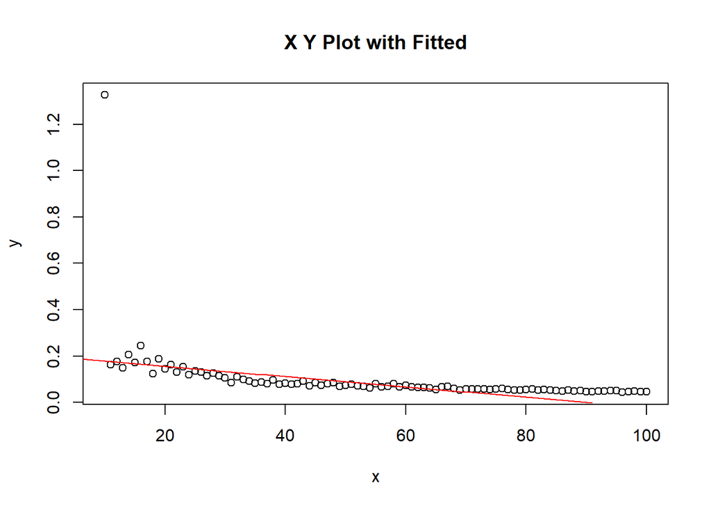

```r
plot(x,y, main='X Y Plot with Fitted')
lines(fitted(m1), col="red")
```

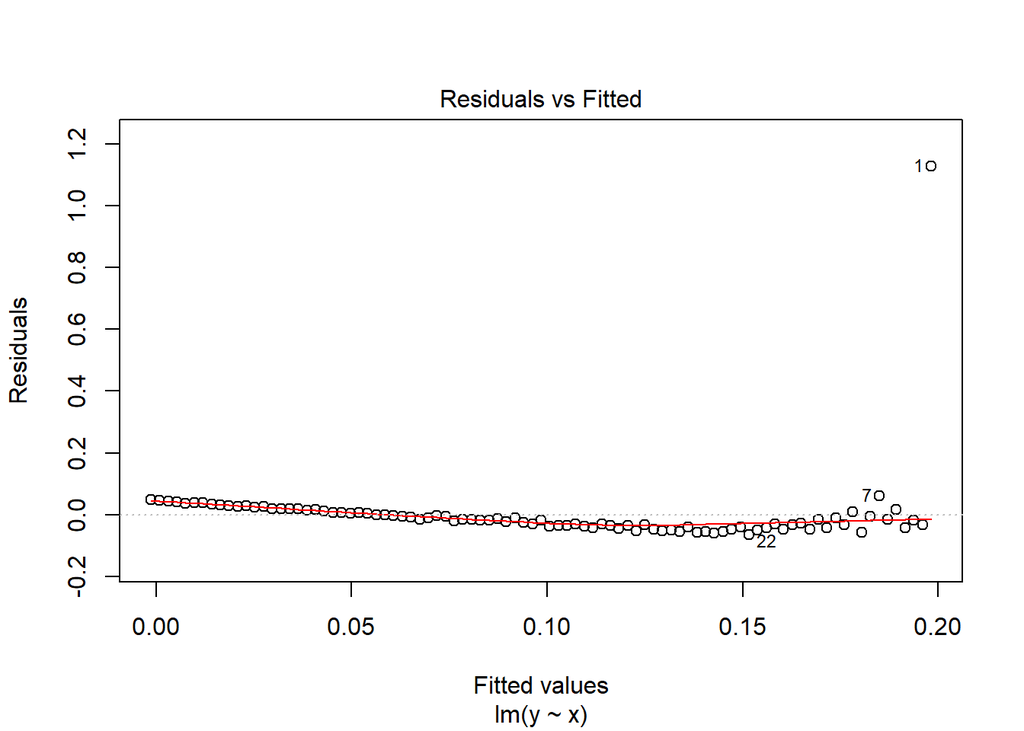

```r
plot(m1, which=1)
```

The plot has a parabolic shape. A possible fix is a power transformation on y, so we run the Box–Cox procedure:

```r
library(MASS)
bc <- boxcox(m1)
```

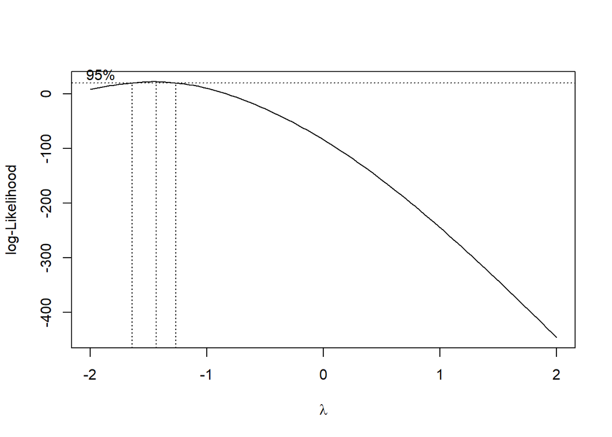

The boxcox function plots values of λ against the log-likelihood of the resulting model. We want to maximize that log-likelihood, so the function draws a line at the best value and also draws lines at the limits of its confidence interval.

Oddly, the boxcox function does not return the best value of λ. Rather, it returns the (x, y) pairs displayed in the plot. It’s pretty easy to find the values of λ that yield the largest log-likelihood y. We use the which.max function:

```r
my_lambda <- bc$x[which.max(bc$y)]
my_lambda
```

```
## [1] -1.434343
```

We can apply the power transform to y and then fit the revised model; this gives a much better R2.

```r
z <- y^my_lambda
m2 <- lm(z ~ x)
summary(m2)
```

```
##
## Call:
## lm(formula = z ~ x)
##
## Residuals:
##      Min       1Q   Median       3Q      Max
## -10.6916  -3.1075   0.1362   2.8507  10.3736
##
## Coefficients:
##             Estimate Std. Error t value Pr(>|t|)
## (Intercept)  0.10754    1.09677   0.098    0.922
## x            0.82215    0.01799  45.689   <2e-16 ***
## ---
## Signif. codes:  0 '***' 0.001 '**' 0.01 '*' 0.05 '.' 0.1 ' ' 1
##
## Residual standard error: 4.509 on 89 degrees of freedom
## Multiple R-squared:  0.9591, Adjusted R-squared:  0.9586
## F-statistic:  2088 on 1 and 89 DF,  p-value: < 2.2e-16
```

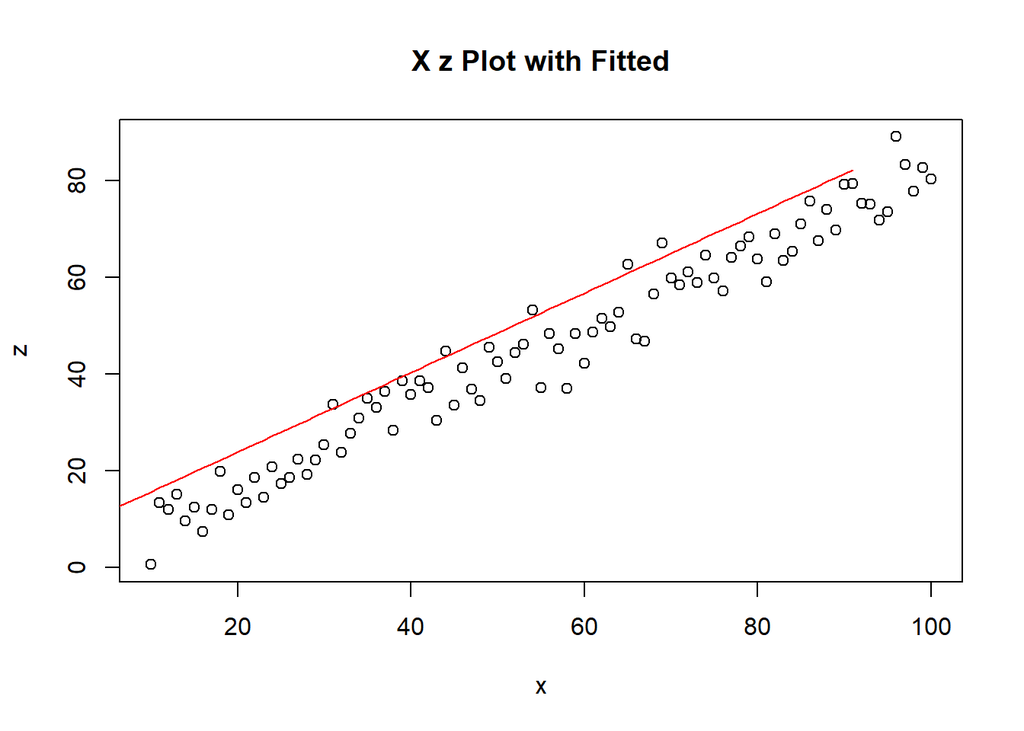

```r
plot(x,z, main='X z Plot with Fitted')
lines(fitted(m2), col="red")
```

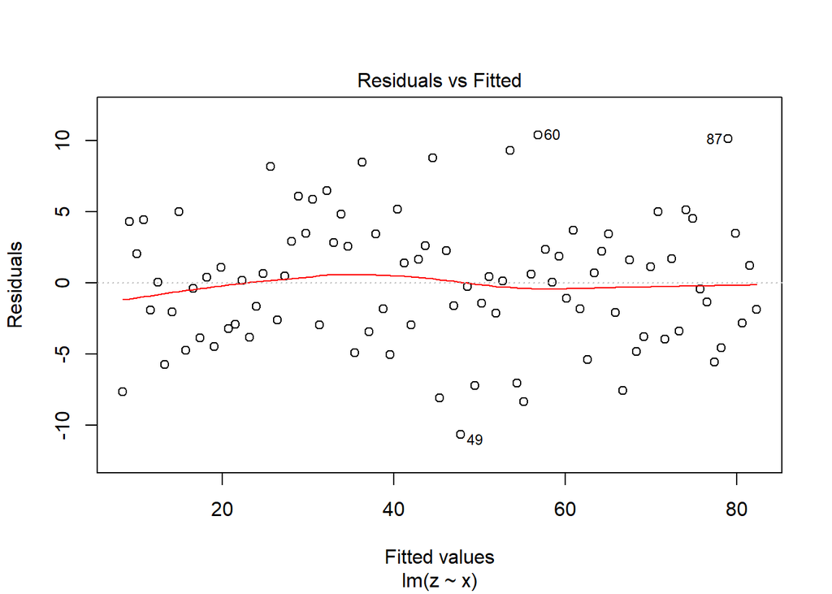

```r
plot(m2, which=1)
```

You have performed a linear regression. Now you want to verify the model’s quality by running diagnostic checks.

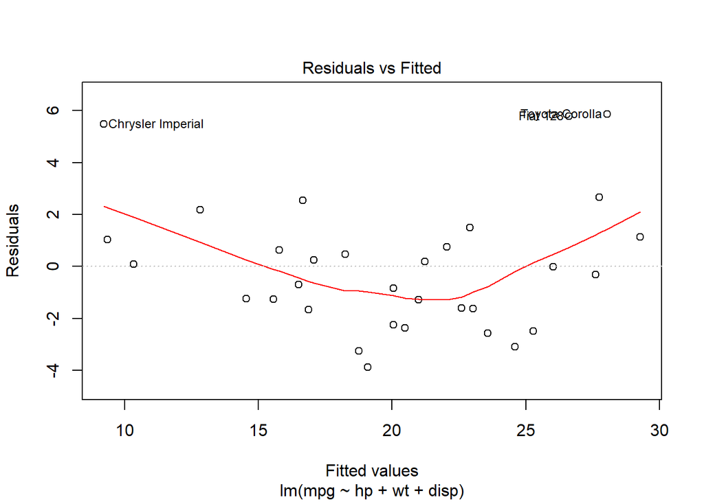

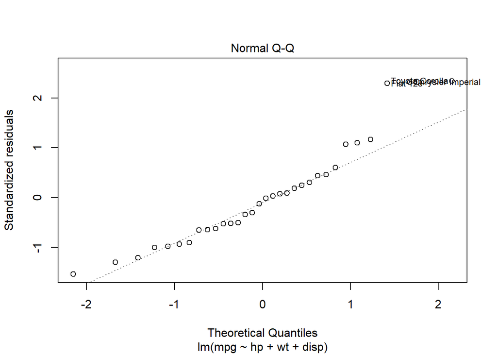

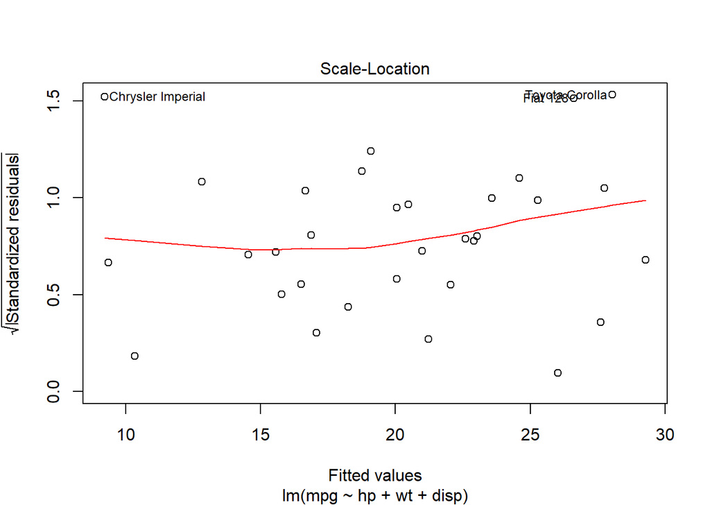

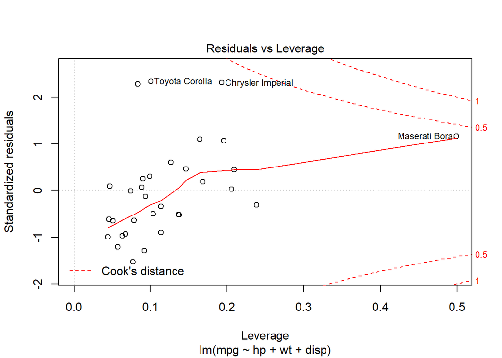

```r
plot(m)
```

car Package (Companion to Applied Regression)

```r
library(car)
outlierTest(m)
```

```
##
## No Studentized residuals with Bonferonni p < 0.05
## Largest |rstudent|:
##                rstudent unadjusted p-value Bonferonni p
## Toyota Corolla 2.564129           0.016225      0.51919
```

You want to identify the observations that are having the most influence on the regression model. This is useful for diagnosing possible problems with the data.

```r
m = lm(mpg ~ wt + hp + qsec, data=mtcars)
summary(influence.measures(m))
```

```
## Potentially influential observations of
##   lm(formula = mpg ~ wt + hp + qsec, data = mtcars) :
##
##                   dfb.1_ dfb.wt dfb.hp dfb.qsec dffit   cov.r   cook.d
## Merc 230           0.47   0.20  -0.31  -0.48    -0.52    2.04_*  0.07
## Chrysler Imperial -0.10   0.85  -0.15  -0.08     1.27_*  0.56_*  0.33
## Fiat 128          -0.05  -0.23  -0.05   0.17     0.75    0.56_*  0.12
## Ford Pantera L    -0.01   0.08  -0.08   0.01    -0.15    1.44_*  0.01
## Maserati Bora     -0.28  -0.46   0.60   0.28     0.72    1.98_*  0.13
##                   hat
## Merc 230           0.46_*
## Chrysler Imperial  0.19
## Fiat 128           0.08
## Ford Pantera L     0.20
## Maserati Bora      0.47_*
```

In linear and nonlinear regression, it is assumed that the residuals are independent of (not correlated with) each other. If the independence assumption is violated, some model fitting results might not be reliable. You can check for this a couple ways:  
1) Use a graph of residuals versus data order (1, 2, 3, 4, n) to visually inspect residuals for autocorrelation. A positive autocorrelation is identified by a clustering of residuals with the same sign. A negative autocorrelation is identified by fast changes in the signs of consecutive residuals.

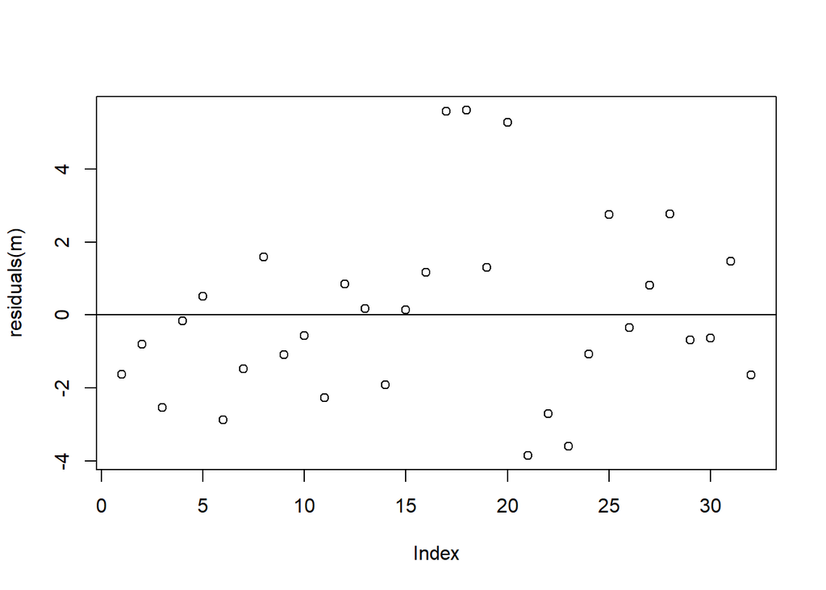

```r
plot(residuals(m))
abline(h=0)
```

2. Use the Durbin-Watson statistic to test for the presence of autocorrelation.

```r
library(lmtest)
dwtest(m, alternative="two.sided")
```

```
##
##  Durbin-Watson test
##
## data:  m
## DW = 1.4224, p-value = 0.05914
## alternative hypothesis: true autocorrelation is not 0
```

Conventionally, if p < 0.05 then the residuals are significantly correlated whereas p > 0.05 provides no evidence of correlation.

*BSS (or treatment SS):* Between (treatment) group SSE. Average of each treatment group minus grand mean. *WSS:* Withing group SSE. Observation minus group mean.* TSS:* Total; BSS+WSS (Hence, you only need to compute any two of three sources of variation to conduct an ANOVA).

Additional calculations based on the square errors gets you a test statistic and ciritcal value for a hypothesis test (based on an F distribution - The F a right-skewed distribution used most commonly in Analysis of Variance).

Using a dichotomous independent variable, the ANOVA table in bivariate regression will have the same numbers and ANOVA results as a one-way ANOVA table would.